# Optimal Treatment Analysis

## Outcome Variable

**Outcome Variable:** whz

## Predictor Variables

**Intervention Variable:** impsan

**Adjustment Set:**

- arm
- sex
- W_mage
- meducyrs
- feducyrs
- hhwealth_quart
- hfoodsec
- W_mhtcm
- W_mwtkg
- W_mbmi
- W_nrooms
- W_nchldlt5
- W_parity
- impfloor
- safeh20
- delta_W_mage
- delta_meducyrs
- delta_feducyrs
- delta_hhwealth_quart
- delta_hfoodsec
- delta_W_mhtcm
- delta_W_mwtkg
- delta_W_mbmi
- delta_W_nrooms
- delta_W_nchldlt5
- delta_W_parity
- delta_impfloor
- delta_safeh20

## Stratifying Variables

The analysis was stratified on these variable(s):

- agecat
- studyid
- country

## Data Summary

| agecat | studyid | country | impsan | n_cell | n |
| --- | --- | --- | --- | --- | --- |
| Birth | ki0047075b-MAL-ED | BANGLADESH | 1 | 168 | 201 |
| Birth | ki0047075b-MAL-ED | BANGLADESH | 0 | 33 | 201 |
| Birth | ki0047075b-MAL-ED | BRAZIL | 1 | 56 | 57 |
| Birth | ki0047075b-MAL-ED | BRAZIL | 0 | 1 | 57 |
| Birth | ki0047075b-MAL-ED | INDIA | 1 | 14 | 39 |
| Birth | ki0047075b-MAL-ED | INDIA | 0 | 25 | 39 |
| Birth | ki0047075b-MAL-ED | NEPAL | 1 | 24 | 25 |
| Birth | ki0047075b-MAL-ED | NEPAL | 0 | 1 | 25 |
| Birth | ki0047075b-MAL-ED | PERU | 1 | 50 | 203 |
| Birth | ki0047075b-MAL-ED | PERU | 0 | 153 | 203 |
| Birth | ki0047075b-MAL-ED | SOUTH AFRICA | 1 | 0 | 94 |
| Birth | ki0047075b-MAL-ED | SOUTH AFRICA | 0 | 94 | 94 |
| Birth | ki0047075b-MAL-ED | TANZANIA, UNITED REPUBLIC OF | 1 | 0 | 110 |
| Birth | ki0047075b-MAL-ED | TANZANIA, UNITED REPUBLIC OF | 0 | 110 | 110 |
| Birth | ki1017093-NIH-Birth | BANGLADESH | 1 | 222 | 575 |
| Birth | ki1017093-NIH-Birth | BANGLADESH | 0 | 353 | 575 |
| Birth | ki1017093b-PROVIDE | BANGLADESH | 1 | 43 | 45 |
| Birth | ki1017093b-PROVIDE | BANGLADESH | 0 | 2 | 45 |
| Birth | ki1017093c-NIH-Crypto | BANGLADESH | 1 | 610 | 696 |
| Birth | ki1017093c-NIH-Crypto | BANGLADESH | 0 | 86 | 696 |
| Birth | ki1114097-CONTENT | PERU | 1 | 1 | 2 |
| Birth | ki1114097-CONTENT | PERU | 0 | 1 | 2 |
| Birth | ki1135781-COHORTS | GUATEMALA | 1 | 43 | 449 |
| Birth | ki1135781-COHORTS | GUATEMALA | 0 | 406 | 449 |
| Birth | ki1135781-COHORTS | INDIA | 1 | 1685 | 4461 |
| Birth | ki1135781-COHORTS | INDIA | 0 | 2776 | 4461 |
| Birth | ki1135781-COHORTS | PHILIPPINES | 1 | 177 | 1126 |
| Birth | ki1135781-COHORTS | PHILIPPINES | 0 | 949 | 1126 |
| Birth | kiGH5241-JiVitA-3 | BANGLADESH | 1 | 12413 | 17991 |
| Birth | kiGH5241-JiVitA-3 | BANGLADESH | 0 | 5578 | 17991 |

[output cut: 70 more lines]

The following strata were considered:

- agecat: 24 months, studyid: ki0047075b-MAL-ED, country: BANGLADESH
- agecat: 24 months, studyid: ki0047075b-MAL-ED, country: BRAZIL
- agecat: 24 months, studyid: ki0047075b-MAL-ED, country: INDIA
- agecat: 24 months, studyid: ki0047075b-MAL-ED, country: NEPAL
- agecat: 24 months, studyid: ki0047075b-MAL-ED, country: PERU
- agecat: 24 months, studyid: ki0047075b-MAL-ED, country: SOUTH AFRICA
- agecat: 24 months, studyid: ki0047075b-MAL-ED, country: TANZANIA, UNITED REPUBLIC OF
- agecat: 24 months, studyid: ki1017093-NIH-Birth, country: BANGLADESH
- agecat: 24 months, studyid: ki1017093b-PROVIDE, country: BANGLADESH
- agecat: 24 months, studyid: ki1017093c-NIH-Crypto, country: BANGLADESH
- agecat: 24 months, studyid: ki1114097-CONTENT, country: PERU
- agecat: 24 months, studyid: ki1135781-COHORTS, country: GUATEMALA
- agecat: 24 months, studyid: ki1135781-COHORTS, country: INDIA
- agecat: 24 months, studyid: ki1135781-COHORTS, country: PHILIPPINES
- agecat: 24 months, studyid: ki1148112-LCNI-5, country: MALAWI
- agecat: 24 months, studyid: kiGH5241-JiVitA-3, country: BANGLADESH
- agecat: 24 months, studyid: kiGH5241-JiVitA-4, country: BANGLADESH
- agecat: 6 months, studyid: ki0047075b-MAL-ED, country: BANGLADESH
- agecat: 6 months, studyid: ki0047075b-MAL-ED, country: BRAZIL
- agecat: 6 months, studyid: ki0047075b-MAL-ED, country: INDIA
- agecat: 6 months, studyid: ki0047075b-MAL-ED, country: NEPAL
- agecat: 6 months, studyid: ki0047075b-MAL-ED, country: PERU
- agecat: 6 months, studyid: ki0047075b-MAL-ED, country: SOUTH AFRICA
- agecat: 6 months, studyid: ki0047075b-MAL-ED, country: TANZANIA, UNITED REPUBLIC OF
- agecat: 6 months, studyid: ki1017093-NIH-Birth, country: BANGLADESH
- agecat: 6 months, studyid: ki1017093b-PROVIDE, country: BANGLADESH
- agecat: 6 months, studyid: ki1017093c-NIH-Crypto, country: BANGLADESH
- agecat: 6 months, studyid: ki1114097-CONTENT, country: PERU
- agecat: 6 months, studyid: ki1135781-COHORTS, country: GUATEMALA
- agecat: 6 months, studyid: ki1135781-COHORTS, country: INDIA
- agecat: 6 months, studyid: ki1135781-COHORTS, country: PHILIPPINES
- agecat: 6 months, studyid: ki1148112-LCNI-5, country: MALAWI
- agecat: 6 months, studyid: kiGH5241-JiVitA-3, country: BANGLADESH
- agecat: 6 months, studyid: kiGH5241-JiVitA-4, country: BANGLADESH
- agecat: Birth, studyid: ki0047075b-MAL-ED, country: BANGLADESH
- agecat: Birth, studyid: ki0047075b-MAL-ED, country: BRAZIL
- agecat: Birth, studyid: ki0047075b-MAL-ED, country: INDIA
- agecat: Birth, studyid: ki0047075b-MAL-ED, country: NEPAL
- agecat: Birth, studyid: ki0047075b-MAL-ED, country: PERU
- agecat: Birth, studyid: ki0047075b-MAL-ED, country: SOUTH AFRICA
- agecat: Birth, studyid: ki0047075b-MAL-ED, country: TANZANIA, UNITED REPUBLIC OF
- agecat: Birth, studyid: ki1017093-NIH-Birth, country: BANGLADESH
- agecat: Birth, studyid: ki1017093b-PROVIDE, country: BANGLADESH
- agecat: Birth, studyid: ki1017093c-NIH-Crypto, country: BANGLADESH
- agecat: Birth, studyid: ki1114097-CONTENT, country: PERU
- agecat: Birth, studyid: ki1135781-COHORTS, country: GUATEMALA
- agecat: Birth, studyid: ki1135781-COHORTS, country: INDIA
- agecat: Birth, studyid: ki1135781-COHORTS, country: PHILIPPINES
- agecat: Birth, studyid: kiGH5241-JiVitA-3, country: BANGLADESH
- agecat: Birth, studyid: kiGH5241-JiVitA-4, country: BANGLADESH

### Dropped Strata

- agecat: Birth, studyid: ki0047075b-MAL-ED, country: BRAZIL
- agecat: Birth, studyid: ki0047075b-MAL-ED, country: NEPAL
- agecat: Birth, studyid: ki0047075b-MAL-ED, country: SOUTH AFRICA
- agecat: Birth, studyid: ki0047075b-MAL-ED, country: TANZANIA, UNITED REPUBLIC OF
- agecat: Birth, studyid: ki1017093b-PROVIDE, country: BANGLADESH
- agecat: Birth, studyid: ki1114097-CONTENT, country: PERU
- agecat: 6 months, studyid: ki0047075b-MAL-ED, country: BRAZIL
- agecat: 6 months, studyid: ki0047075b-MAL-ED, country: NEPAL
- agecat: 6 months, studyid: ki0047075b-MAL-ED, country: SOUTH AFRICA
- agecat: 6 months, studyid: ki0047075b-MAL-ED, country: TANZANIA, UNITED REPUBLIC OF
- agecat: 6 months, studyid: ki1017093b-PROVIDE, country: BANGLADESH
- agecat: 6 months, studyid: ki1148112-LCNI-5, country: MALAWI
- agecat: 24 months, studyid: ki0047075b-MAL-ED, country: BRAZIL
- agecat: 24 months, studyid: ki0047075b-MAL-ED, country: NEPAL
- agecat: 24 months, studyid: ki0047075b-MAL-ED, country: SOUTH AFRICA
- agecat: 24 months, studyid: ki0047075b-MAL-ED, country: TANZANIA, UNITED REPUBLIC OF
- agecat: 24 months, studyid: ki1017093b-PROVIDE, country: BANGLADESH
- agecat: 24 months, studyid: ki1148112-LCNI-5, country: MALAWI

## Methods Detail

We’re interested in the causal parameters $E[Y_a]$ for all values of $a \in \mathcal{A}$. These parameters represent the mean outcome if, possibly contrary to fact, we intervened to set all units to have $A=a$. Under the randomization and positivity assumptions, these are identified by the statistical parameters $\psi_a=E_W[E_{Y|A,W}(Y|A=a,W)]$. In addition, we’re interested in the mean of $Y$, $E[Y]$ under no intervention (the observed mean). We will estimate these parameters by using SuperLearner to fit the relevant likelihood factors – $E_{Y|A,W}(Y|A=a,W)$ and $p(A=a|W)$, and then updating our likelihood fit using a joint TMLE.

For unadjusted analyses ($W=\{\}$), initial likelihoods were estimated using Lrnr_glm to estimate the simple $E(Y|A)$ and Lrnr_mean to estimate $p(A)$. For adjusted analyses, a small library containing Lrnr_glmnet, Lrnr_xgboost, and Lrnr_mean was used.

Having estimated these parameters, we will then use the delta method to estimate relative risks and attributable risks relative to a prespecified baseline level of $A$.

# Results Detail

## Results Plots

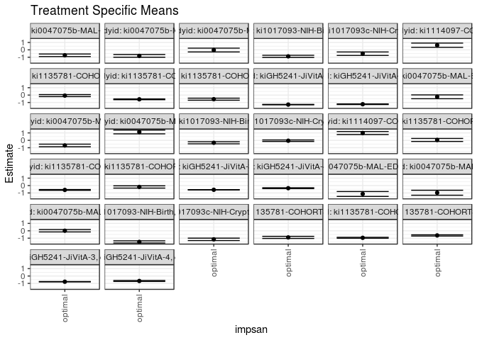

## Results Table

### Parameter: TSM

| agecat | studyid | country | intervention_level | baseline_level | estimate | ci_lower | ci_upper |
| --- | --- | --- | --- | --- | --- | --- | --- |
| Birth | ki0047075b-MAL-ED | BANGLADESH | optimal | observed | -1.1371047 | -1.4665740 | -0.8076353 |
| Birth | ki0047075b-MAL-ED | INDIA | optimal | observed | -0.9718927 | -1.3072022 | -0.6365833 |
| Birth | ki0047075b-MAL-ED | PERU | optimal | observed | 0.0075902 | -0.1554591 | 0.1706394 |
| Birth | ki1017093-NIH-Birth | BANGLADESH | optimal | observed | -1.5021146 | -1.6487895 | -1.3554397 |
| Birth | ki1017093c-NIH-Crypto | BANGLADESH | optimal | observed | -1.1577242 | -1.3193909 | -0.9960575 |
| Birth | ki1135781-COHORTS | GUATEMALA | optimal | observed | -0.8950304 | -1.0384891 | -0.7515717 |
| Birth | ki1135781-COHORTS | INDIA | optimal | observed | -0.9491831 | -1.0109307 | -0.8874355 |
| Birth | ki1135781-COHORTS | PHILIPPINES | optimal | observed | -0.6278168 | -0.7124946 | -0.5431391 |
| Birth | kiGH5241-JiVitA-3 | BANGLADESH | optimal | observed | -0.7701189 | -0.7934078 | -0.7468299 |
| Birth | kiGH5241-JiVitA-4 | BANGLADESH | optimal | observed | -0.6708117 | -0.7346089 | -0.6070144 |
| 6 months | ki0047075b-MAL-ED | BANGLADESH | optimal | observed | -0.2331299 | -0.4916799 | 0.0254201 |
| 6 months | ki0047075b-MAL-ED | INDIA | optimal | observed | -0.6948676 | -0.8718282 | -0.5179070 |
| 6 months | ki0047075b-MAL-ED | PERU | optimal | observed | 1.1303890 | 0.8731159 | 1.3876621 |
| 6 months | ki1017093-NIH-Birth | BANGLADESH | optimal | observed | -0.3326157 | -0.4732056 | -0.1920257 |
| 6 months | ki1017093c-NIH-Crypto | BANGLADESH | optimal | observed | -0.0535274 | -0.1556763 | 0.0486215 |
| 6 months | ki1114097-CONTENT | PERU | optimal | observed | 0.9868709 | 0.7806772 | 1.1930647 |
| 6 months | ki1135781-COHORTS | GUATEMALA | optimal | observed | 0.0490734 | -0.1553380 | 0.2534849 |
| 6 months | ki1135781-COHORTS | INDIA | optimal | observed | -0.5923622 | -0.6465508 | -0.5381736 |
| 6 months | ki1135781-COHORTS | PHILIPPINES | optimal | observed | -0.1902827 | -0.3430443 | -0.0375211 |
| 6 months | kiGH5241-JiVitA-3 | BANGLADESH | optimal | observed | -0.5733851 | -0.5964283 | -0.5503420 |
| 6 months | kiGH5241-JiVitA-4 | BANGLADESH | optimal | observed | -0.3566565 | -0.4142581 | -0.2990550 |
| 24 months | ki0047075b-MAL-ED | BANGLADESH | optimal | observed | -0.7332857 | -0.9062563 | -0.5603152 |
| 24 months | ki0047075b-MAL-ED | INDIA | optimal | observed | -0.8167312 | -0.9980836 | -0.6353787 |
| 24 months | ki0047075b-MAL-ED | PERU | optimal | observed | -0.0274097 | -0.2844797 | 0.2296603 |
| 24 months | ki1017093-NIH-Birth | BANGLADESH | optimal | observed | -0.8802533 | -1.0242773 | -0.7362293 |
| 24 months | ki1017093c-NIH-Crypto | BANGLADESH | optimal | observed | -0.5195867 | -0.7518345 | -0.2873389 |
| 24 months | ki1114097-CONTENT | PERU | optimal | observed | 0.6258121 | 0.3375349 | 0.9140892 |
| 24 months | ki1135781-COHORTS | GUATEMALA | optimal | observed | -0.0710963 | -0.2081417 | 0.0659492 |
| 24 months | ki1135781-COHORTS | INDIA | optimal | observed | -0.5706416 | -0.6237384 | -0.5175447 |
| 24 months | ki1135781-COHORTS | PHILIPPINES | optimal | observed | -0.5540938 | -0.6929245 | -0.4152630 |
| 24 months | kiGH5241-JiVitA-3 | BANGLADESH | optimal | observed | -1.2864087 | -1.3155778 | -1.2572397 |
| 24 months | kiGH5241-JiVitA-4 | BANGLADESH | optimal | observed | -1.2335560 | -1.2735883 | -1.1935237 |

### Parameter: E(Y)

| agecat | studyid | country | intervention_level | baseline_level | estimate | ci_lower | ci_upper |
| --- | --- | --- | --- | --- | --- | --- | --- |
| Birth | ki0047075b-MAL-ED | BANGLADESH | observed | observed | -0.9728358 | -1.1217009 | -0.8239707 |
| Birth | ki0047075b-MAL-ED | INDIA | observed | observed | -0.9441026 | -1.2397919 | -0.6484132 |
| Birth | ki0047075b-MAL-ED | PERU | observed | observed | -0.0381281 | -0.1669868 | 0.0907307 |
| Birth | ki1017093-NIH-Birth | BANGLADESH | observed | observed | -1.3499217 | -1.4444634 | -1.2553801 |
| Birth | ki1017093c-NIH-Crypto | BANGLADESH | observed | observed | -1.2402802 | -1.3249395 | -1.1556208 |
| Birth | ki1135781-COHORTS | GUATEMALA | observed | observed | -0.9294432 | -1.0701697 | -0.7887168 |
| Birth | ki1135781-COHORTS | INDIA | observed | observed | -0.9771733 | -1.0119896 | -0.9423570 |
| Birth | ki1135781-COHORTS | PHILIPPINES | observed | observed | -0.6841030 | -0.7582767 | -0.6099293 |
| Birth | kiGH5241-JiVitA-3 | BANGLADESH | observed | observed | -0.7777528 | -0.7967725 | -0.7587330 |
| Birth | kiGH5241-JiVitA-4 | BANGLADESH | observed | observed | -0.6882498 | -0.7406539 | -0.6358456 |
| 6 months | ki0047075b-MAL-ED | BANGLADESH | observed | observed | -0.1333333 | -0.2623761 | -0.0042906 |
| 6 months | ki0047075b-MAL-ED | INDIA | observed | observed | -0.7018062 | -0.8289790 | -0.5746333 |
| 6 months | ki0047075b-MAL-ED | PERU | observed | observed | 1.0372972 | 0.9141109 | 1.1604836 |
| 6 months | ki1017093-NIH-Birth | BANGLADESH | observed | observed | -0.4474038 | -0.5378167 | -0.3569909 |
| 6 months | ki1017093c-NIH-Crypto | BANGLADESH | observed | observed | 0.0336790 | -0.0458848 | 0.1132428 |
| 6 months | ki1114097-CONTENT | PERU | observed | observed | 1.0684318 | 0.9515274 | 1.1853362 |
| 6 months | ki1135781-COHORTS | GUATEMALA | observed | observed | 0.1458511 | 0.0589571 | 0.2327450 |
| 6 months | ki1135781-COHORTS | INDIA | observed | observed | -0.7104855 | -0.7428053 | -0.6781657 |
| 6 months | ki1135781-COHORTS | PHILIPPINES | observed | observed | -0.2830286 | -0.3471028 | -0.2189545 |
| 6 months | kiGH5241-JiVitA-3 | BANGLADESH | observed | observed | -0.5931476 | -0.6127125 | -0.5735828 |
| 6 months | kiGH5241-JiVitA-4 | BANGLADESH | observed | observed | -0.3901595 | -0.4274150 | -0.3529041 |
| 24 months | ki0047075b-MAL-ED | BANGLADESH | observed | observed | -0.8192925 | -0.9412667 | -0.6973182 |
| 24 months | ki0047075b-MAL-ED | INDIA | observed | observed | -0.9490222 | -1.0651720 | -0.8328724 |
| 24 months | ki0047075b-MAL-ED | PERU | observed | observed | 0.0972406 | -0.0271085 | 0.2215898 |
| 24 months | ki1017093-NIH-Birth | BANGLADESH | observed | observed | -0.9115790 | -1.0095022 | -0.8136559 |
| 24 months | ki1017093c-NIH-Crypto | BANGLADESH | observed | observed | -0.6115706 | -0.7075788 | -0.5155624 |
| 24 months | ki1114097-CONTENT | PERU | observed | observed | 0.5668293 | 0.4302437 | 0.7034148 |
| 24 months | ki1135781-COHORTS | GUATEMALA | observed | observed | -0.2861905 | -0.3461594 | -0.2262216 |
| 24 months | ki1135781-COHORTS | INDIA | observed | observed | -0.6606874 | -0.6938402 | -0.6275347 |
| 24 months | ki1135781-COHORTS | PHILIPPINES | observed | observed | -0.6564149 | -0.7144543 | -0.5983756 |
| 24 months | kiGH5241-JiVitA-3 | BANGLADESH | observed | observed | -1.2970418 | -1.3203361 | -1.2737475 |
| 24 months | kiGH5241-JiVitA-4 | BANGLADESH | observed | observed | -1.2231776 | -1.2550332 | -1.1913220 |

### Parameter: PAR

| agecat | studyid | country | intervention_level | baseline_level | estimate | ci_lower | ci_upper |
| --- | --- | --- | --- | --- | --- | --- | --- |
| Birth | ki0047075b-MAL-ED | BANGLADESH | optimal | observed | 0.1642689 | -0.1340185 | 0.4625562 |
| Birth | ki0047075b-MAL-ED | INDIA | optimal | observed | 0.0277902 | -0.2523505 | 0.3079308 |
| Birth | ki0047075b-MAL-ED | PERU | optimal | observed | -0.0457182 | -0.1202525 | 0.0288160 |
| Birth | ki1017093-NIH-Birth | BANGLADESH | optimal | observed | 0.1521929 | 0.0468342 | 0.2575515 |
| Birth | ki1017093c-NIH-Crypto | BANGLADESH | optimal | observed | -0.0825560 | -0.2187285 | 0.0536166 |
| Birth | ki1135781-COHORTS | GUATEMALA | optimal | observed | -0.0344128 | -0.0910033 | 0.0221777 |
| Birth | ki1135781-COHORTS | INDIA | optimal | observed | -0.0279902 | -0.0775755 | 0.0215952 |
| Birth | ki1135781-COHORTS | PHILIPPINES | optimal | observed | -0.0562862 | -0.0967778 | -0.0157946 |
| Birth | kiGH5241-JiVitA-3 | BANGLADESH | optimal | observed | -0.0076339 | -0.0211888 | 0.0059211 |
| Birth | kiGH5241-JiVitA-4 | BANGLADESH | optimal | observed | -0.0174381 | -0.0586546 | 0.0237783 |
| 6 months | ki0047075b-MAL-ED | BANGLADESH | optimal | observed | 0.0997966 | -0.1292585 | 0.3288517 |
| 6 months | ki0047075b-MAL-ED | INDIA | optimal | observed | -0.0069386 | -0.1412091 | 0.1273320 |
| 6 months | ki0047075b-MAL-ED | PERU | optimal | observed | -0.0930918 | -0.3100219 | 0.1238383 |
| 6 months | ki1017093-NIH-Birth | BANGLADESH | optimal | observed | -0.1147881 | -0.2285999 | -0.0009764 |
| 6 months | ki1017093c-NIH-Crypto | BANGLADESH | optimal | observed | 0.0872064 | 0.0081536 | 0.1662591 |
| 6 months | ki1114097-CONTENT | PERU | optimal | observed | 0.0815608 | -0.0948497 | 0.2579714 |
| 6 months | ki1135781-COHORTS | GUATEMALA | optimal | observed | 0.0967776 | -0.0943968 | 0.2879521 |
| 6 months | ki1135781-COHORTS | INDIA | optimal | observed | -0.1181233 | -0.1629761 | -0.0732705 |
| 6 months | ki1135781-COHORTS | PHILIPPINES | optimal | observed | -0.0927460 | -0.2340836 | 0.0485916 |
| 6 months | kiGH5241-JiVitA-3 | BANGLADESH | optimal | observed | -0.0197625 | -0.0315081 | -0.0080168 |
| 6 months | kiGH5241-JiVitA-4 | BANGLADESH | optimal | observed | -0.0335030 | -0.0764868 | 0.0094808 |
| 24 months | ki0047075b-MAL-ED | BANGLADESH | optimal | observed | -0.0860067 | -0.2284011 | 0.0563876 |
| 24 months | ki0047075b-MAL-ED | INDIA | optimal | observed | -0.1322910 | -0.2599540 | -0.0046281 |
| 24 months | ki0047075b-MAL-ED | PERU | optimal | observed | 0.1246503 | -0.1160816 | 0.3653823 |
| 24 months | ki1017093-NIH-Birth | BANGLADESH | optimal | observed | -0.0313258 | -0.1464615 | 0.0838100 |
| 24 months | ki1017093c-NIH-Crypto | BANGLADESH | optimal | observed | -0.0919839 | -0.3020254 | 0.1180576 |
| 24 months | ki1114097-CONTENT | PERU | optimal | observed | -0.0589828 | -0.3437049 | 0.2257393 |
| 24 months | ki1135781-COHORTS | GUATEMALA | optimal | observed | -0.2150942 | -0.3461125 | -0.0840759 |
| 24 months | ki1135781-COHORTS | INDIA | optimal | observed | -0.0900459 | -0.1317030 | -0.0483888 |
| 24 months | ki1135781-COHORTS | PHILIPPINES | optimal | observed | -0.1023211 | -0.2333778 | 0.0287355 |
| 24 months | kiGH5241-JiVitA-3 | BANGLADESH | optimal | observed | -0.0106330 | -0.0276690 | 0.0064029 |
| 24 months | kiGH5241-JiVitA-4 | BANGLADESH | optimal | observed | 0.0103784 | -0.0155657 | 0.0363225 |